# Bayes Rules Ch 5 Homework

Exercises: 5.5, 5.6, 5.9, 5.10

Author

Matt McGehee

```r
packages <- c("tidyr","dplyr","bayesrules", "ggplot2")

needs_installing <- packages[!packages %in% installed.packages()[,"Package"]]
if(length(needs_installing)) {
  install.packages(needs_installing)
}

for(pkg in packages){
  if(!pkg %in% (.packages())){
    library(pkg, character.only = TRUE)
  }
}
```

## Exercise 5.5 (Text messages)

Let random variable λ represent the rate of text messages people receive in an hour. At first, you believe that the typical number of messages per hour is 5 with a standard deviation of 0.25 messages. a. Tune and plot an appropriate $Gamma(s,r)$ prior model for λ. b. What is the prior probability that the rate of text messages per hour is larger than 10? Hint: learn about $pgamma()$.

Given E[λ]=5 messages per hour and var[λ] = $0.25^2$, we can find r by dividing the mean by the variance: $r = \frac{5}{0.25^2} = 80$.  
The shape $s$ is the mean multiplied by the rate: $s=5\times80=400$

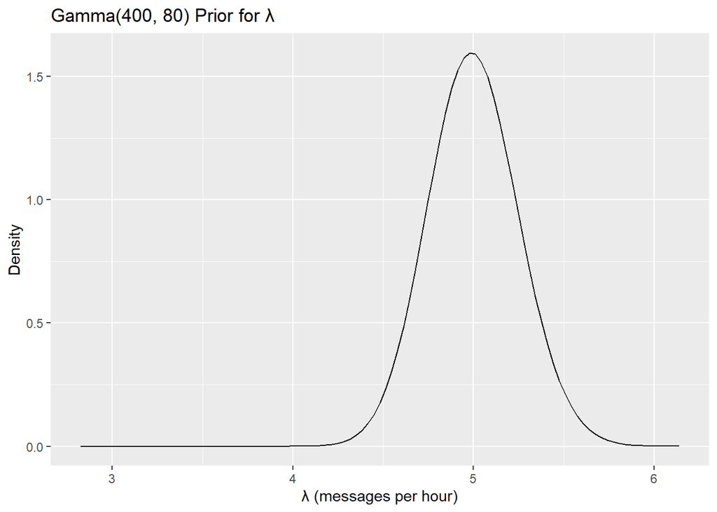

```r
plot_gamma(400, 80) +
  ggtitle("Gamma(400, 80) Prior for λ") +
  xlab("λ (messages per hour)") +
  ylab("Density")
```

Cumulative distribution when $λ > 10$, using $pgamma()$:

```r
(p_gamma <- pgamma(10, shape = 400, rate = 80))
```

```
[1] 1
```

Prior probability is 1 minus the cumulative distribution, so the $P(\lambda > 10)$ is:

```r
(prior_prob <- 1 - p_gamma)
```

```
[1] 0
```

## Exercise 5.6 (Text messages with data)

Continuing with Exercise 5.5, you collect data from six friends. They received 7, 3, 8, 9, 10, 12 text messages in the previous hour.

### a. Plot the resulting likelihood function of λ

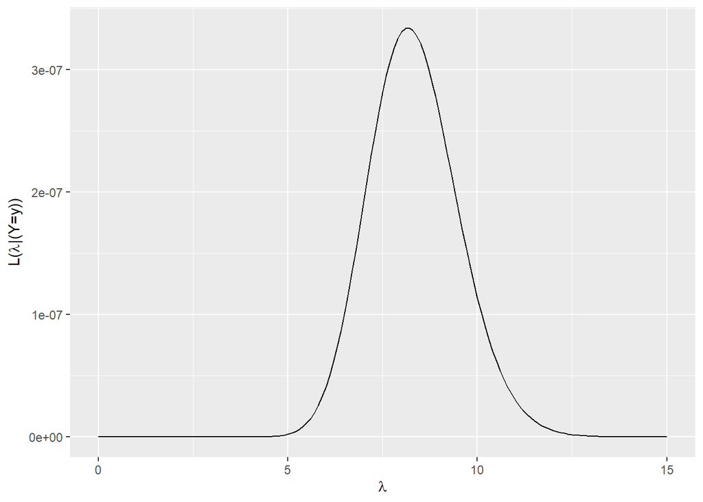

```r
plot_poisson_likelihood(y = c(7,3,8,9,10,12), lambda_upper_bound = 15)
```

### b. Plot the prior pdf, likelihood function, and the posterior pdf of λ

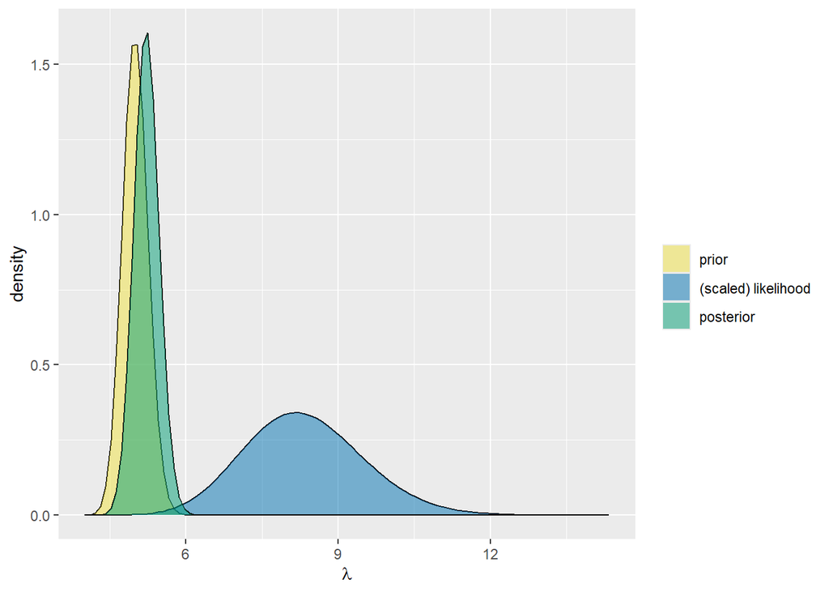

```r
plot_gamma_poisson(shape = 400, rate = 80, sum_y = 49, n = 6)
```

### c. Use summarize_gamma_poisson() to calculate descriptive statistics for the prior and the posterior models of λ

```r
(summarize_gamma_poisson(shape = 400, rate = 80, sum_y = 49, n = 6))
```

```
      model shape rate    mean     mode        var        sd
1     prior   400   80 5.00000 4.987500 0.06250000 0.2500000
2 posterior   449   86 5.22093 5.209302 0.06070849 0.2463909
```

### d. Comment on how your understanding about λ changed from the prior (in the previous exercise) to the posterior based on the data you collected from your friends

The likelihood function has pulled the Posterior PDF for λ to the right, indicating that the E[λ] is slightly to the right of our prior belief. The peak of the posterior is slightly taller as well, which is good, as this indicates a smaller variance in our posterior distribution from the added observations.

## Exercise 5.9 (Investing in stock)

You just bought stock in FancyTech. Let random variable μ be the average dollar amount that your FancyTech stock goes up or down in a one-day period. At first, you believe that μ is 7.2 dollars with a standard deviation of 2.6 dollars.

### a. Tune and plot an appropriate Normal prior model for μ

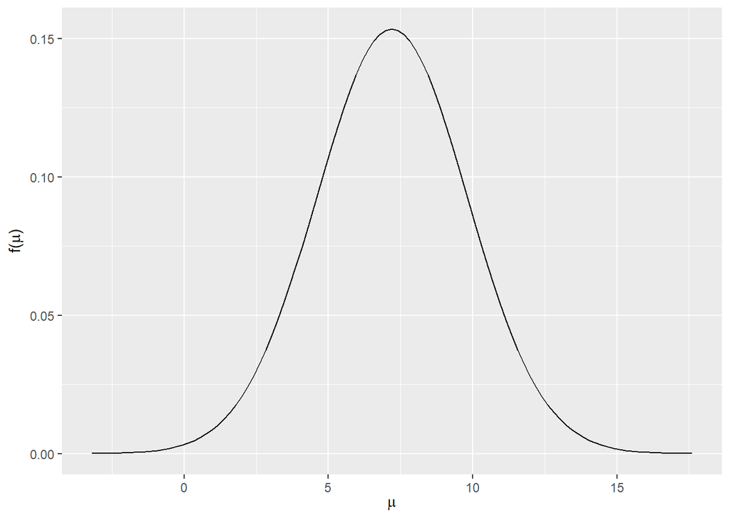

```r
(plot_normal(7.2, 2.6))
```

### b. According to your plot, does it seem plausible that the FancyTech stock would increase by an average of 7.6 dollars in a day?

The mode/peak is close enough to 7.6, that I would say it is plausible.

### c. Does it seem plausible that the FancyTech stock would increase by an average of 4 dollars in a day?

4 is quite left of the mode/peak, but still within 2 standard deviations (lower bound: $7.2-2(2.6)=2.0$), so it is plausible, just less likely than 7.6 dollars in a day.

### d. What is the prior probability that, on average, the stock price goes down? Hint: pnorm().

```r
(round(pnorm(0, 7.2, 2.6), 4))
```

```
[1] 0.0028
```

### e. What is the prior probability that, on average, your stock price goes up by more than 8 dollars per day?

```r
(round(1 - pnorm(8, 7.2, 2.6), 4))
```

```
[1] 0.3792
```

## Exercise 5.10 (Investing in stock with data)

Continuing with Exercise 5.9, it’s reasonable to assume that the daily changes in FancyTech stock value are Normally distributed around an unknown mean of μ with a known standard deviation of σ = 2 dollars. On a random sample of 4 days, you observe changes in stock value of -0.7, 1.2, 4.5, and -4 dollars.

### a. Plot the corresponding likelihood function of μ.

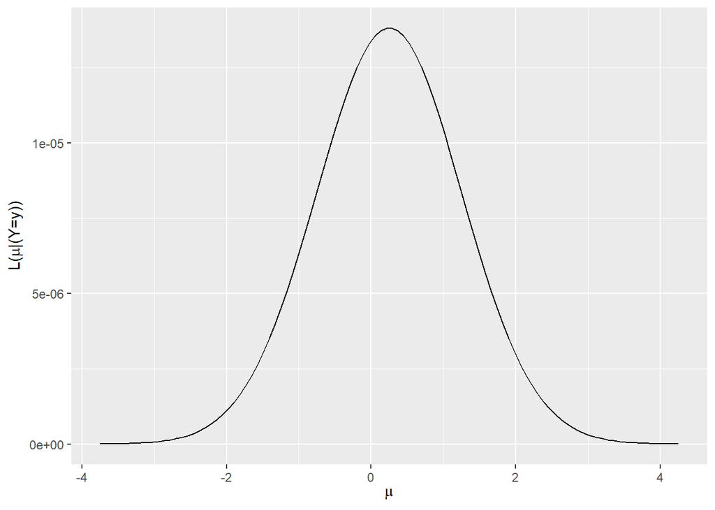

```r
(plot_normal_likelihood(y = c(-0.7,1.2,4.5,-4), sigma = 2))
```

### b. Plot the prior pdf, likelihood function, and the posterior pdf for μ.

y_bar:

```r
mean(c(-0.7,1.2,4.5,-4))
```

```
[1] 0.25
```

Plot:

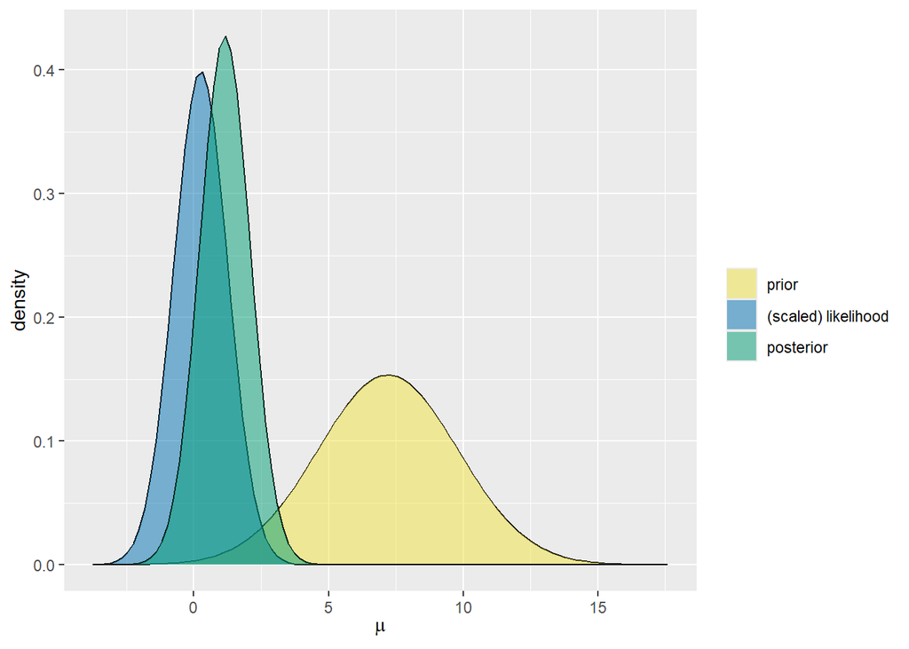

```r
(plot_normal_normal(mean = 7.2, sd = 2.6, sigma = 2, y_bar = 0.25, n = 4))
```

### c. Use summarize_normal_normal() to calculate descriptive statistics for the prior and the posterior models.

```r
(summarize_normal_normal(mean = 7.2, sd = 2.6, sigma = 2, y_bar = 0.25, n = 4))
```

```
      model     mean     mode      var        sd
1     prior 7.200000 7.200000 6.760000 2.6000000
2 posterior 1.145619 1.145619 0.871134 0.9333456
```

### d. Comment on how your understanding about μ evolved from the prior (in the previous exercise) to the posterior based on the observed data.

The observed date generated a likelihood PDF that, in conjunction with our prior PDF, generated a posterior PDF far to the left our our prior belief.

### e. What is the posterior probability that, on average, the stock price goes down? Hint: pnorm().

```r
(round(pnorm(0, mean = 1.1456, sd = 0.9333), 4))
```

```
[1] 0.1098
```

### f. What is the posterior probability that, on average, your stock price goes up by more than 8 dollars per day?

```r
(round(1 - pnorm(8, mean = 1.1456, sd = 0.9333), 4))
```

```
[1] 0
```